# tutorial multivariada

Ciro, Ivan, Jessika, Luana e Morgana

7 de setembro de 2017

Com esse tutorial você vai impressionar seus colegas de trabalho com duas análises multivariadas sofistiacadíssimas, a PCA (análise de componentes principais) e o NMDS (non-metric multidimensional scaling) visualizando os resultados em gráficos do `ggplot2`.

Pra isso, nós vamos usar o famosíssimo dataset `iris` [link](https://www.youtube.com/watch?v=NdYWuo9OFAw) da banda goo goo dolls e a função `prcomp`. Não precisa instalar nada (por enquanto).

O dataset `iris` já vem no R, daí não precisa de muito drama (nada de `read.table` ou `read.csv` e tal, então vamos pular essa parte).

só precisa “falar”

```r
iris
```

e ele aparece

[output not shown]

Nessa parte é bom instalar logo os pacotes que vão ser usados, `ggplot2` e `ggfortify`, pra isso, só seguir os passos abaixo:

Primeiro, instala os bonecos

```r
install.packages("ggplot2")
install.packages("ggfortify")
```

E carrega eles, depois

```r
library(ggplot2)
library(ggfortify)
```

## Agora começa a resenha

**Antes de tudo**

Se vc tentar fazer a PCA sem especificar quais colunas o R tem q ler, vai dar um erro, então, é bom criar um objeto que só tenha `valores`.

Fica um lance mais ou menos assim

```r
iris.val=iris[c(1,2,3,4)]
```

```r
head(iris.val)
```

```
##   Sepal.Length Sepal.Width Petal.Length Petal.Width
## 1          5.1         3.5          1.4         0.2
## 2          4.9         3.0          1.4         0.2
## 3          4.7         3.2          1.3         0.2
## 4          4.6         3.1          1.5         0.2
## 5          5.0         3.6          1.4         0.2
## 6          5.4         3.9          1.7         0.4
```

Agora podemos usar a função `prmcomp` e calcular a PCA

```r
prcomp(iris.val,scale=T)
```

```
## Standard deviations (1, .., p=4):
## [1] 1.7083611 0.9560494 0.3830886 0.1439265
##
## Rotation (n x k) = (4 x 4):
##                     PC1         PC2        PC3        PC4
## Sepal.Length  0.5210659 -0.37741762  0.7195664  0.2612863
## Sepal.Width  -0.2693474 -0.92329566 -0.2443818 -0.1235096
## Petal.Length  0.5804131 -0.02449161 -0.1421264 -0.8014492
## Petal.Width   0.5648565 -0.06694199 -0.6342727  0.5235971
```

Nesse momento vc deve estar se perguntando *pq essxs queridxs resolveram usar o ggplot????*, bom, pq a gente pode… só isso mesmo. E vai ficar uma coisa mais ou menos assim

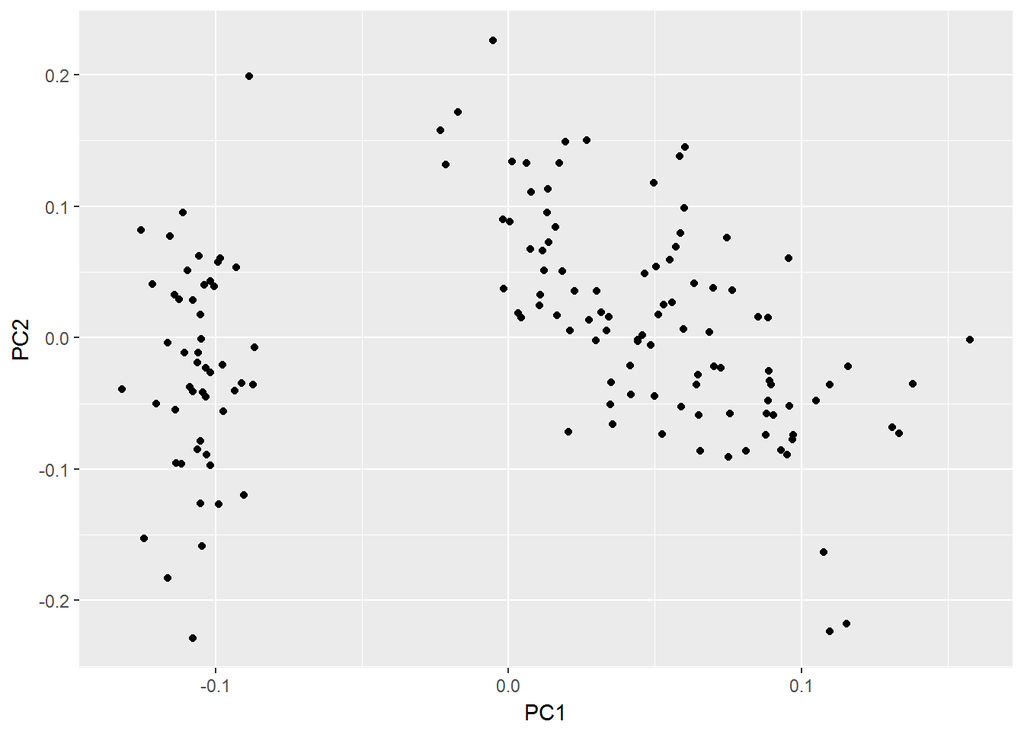

```r
autoplot(prcomp(iris.val,scale=T))
```

Mas não tá tão bonito assim, e nem diz muito coisa, né? Vamo tentar melhorar, põe umas *true colors shining through* [link](https://www.youtube.com/watch?v=LPn0KFlbqX8)

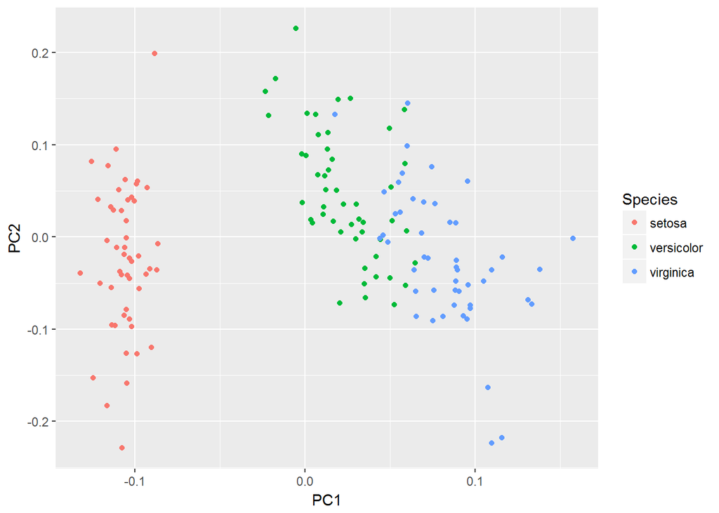

```r
autoplot(prcomp(iris.val,scale=T),data=iris,colour='Species')
```

Ficou mais legal, mas pode ficar AINDA mais, usando a função `frame=T`, assim:

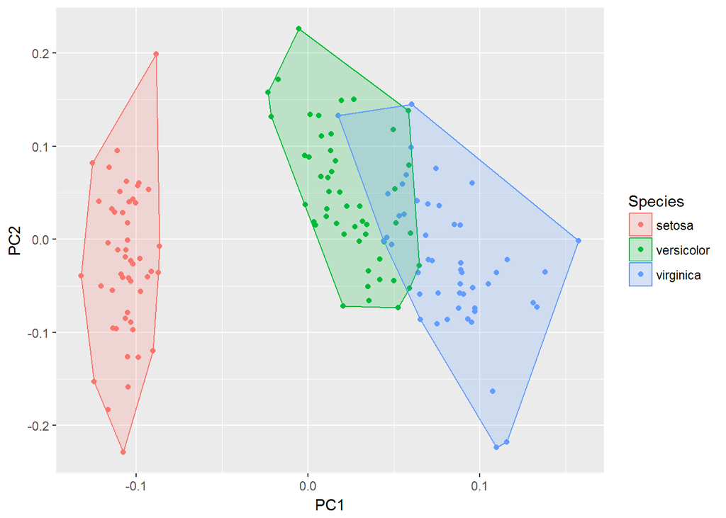

```r
autoplot(prcomp(iris.val,scale=T),data=iris,colour='Species',frame=T)
```

Agora o negócio ficou mais maneiro.

#### Galera, essa foi a primeira parte do tutorial de multivariadas no R, agora vem a segunda (isso mesmo) parte.

Seguindo o bonde, vamos continuar usando `iris` mesmo, pra não ter muito trabalho.

O passo agora é fazer um `nmds`. O famoso pacote `vegan` tem uma função pra isso, a `metaMDS`.

Primeiro é bom instalar o pacote…

```r
install.packages("vegan")
```

E depois carrega o boneco

```r
library(vegan)
```

Se você pulou pra essa parte do tutorial e perdeu as dicas do começo, precisa fazer uma malandragem pra usar o dataset sem os nomes das espécies (tem outra forma de fazer isso lá no começo).

```r
iris_data<-iris[ , 1:4]
```

#### Agora começa a parte da análise em si.

Primeiro vamos criar uma matriz de distância com os valores de Iris

```r
iris_data_euc<-vegdist(iris_data, method="euclidean")
```

Nós usamos duas funções, `try` e `trymax`, pra limitar o mínimo e o máximo de rodadas ou tentativas.

A linha fica desse jeito

```r
nmds.euc<-metaMDS(iris_data_euc, try=20, trymax=50)
```

```
## *** Solution reached
```

Daí você quer ver um gráfico disso, certo?

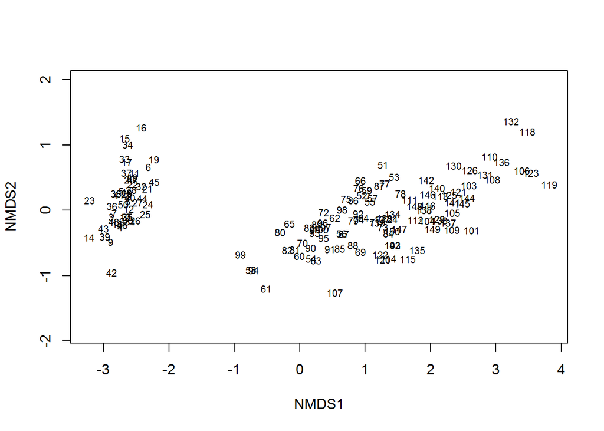

```r
plot(nmds.euc, type="t")
```

Eu sei… pode ser melhor. Aqui você poderia tentar o `ggplot`, como na análise anterior, mas eu vou passar pra vocês o que chamamos de modo oldschool…

Primeiro vamos dar nome aos bois (ou às plantas, sei lá…).

```r
as.data.frame(iris[ ,5])
```

```r
sp_iris=iris[,5]
```

Agora vamo fazer o grÃ¡fico *oldschool*

Primeiro escolhe as cores das espécies

```r
cores.sp<-c("blue", "red", "green")
```

Agora, vamos ao gráfico

```r
plot(nmds.euc, type="n")
points(nmds.euc, pch=16, col=cores.sp[sp_iris])
ordihull(nmds.euc,sp_iris, col=cores.sp)
```

Se executar cada linha dessas uma após a outra você vai ter mais ou menos isso

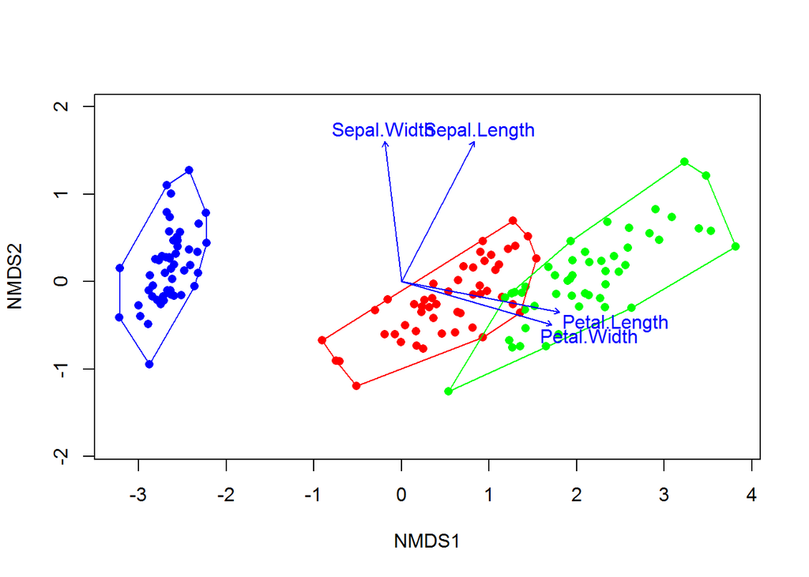

```r
plot(nmds.euc, type="n")
points(nmds.euc, pch=16, col=cores.sp[sp_iris])
ordihull(nmds.euc,sp_iris, col=cores.sp)
envfit.euc<-envfit(nmds.euc, iris_data)
plot(envfit.euc)
```

#### E é isso, rapeize, espero que tenha sido instrutivo. Qualquer dúvida, é só entrar em contato com xs autorxs ou buscar as cheat sheets dos pacotes no google.